# Does high-intensity physical exercise affect memorisation?

Maarten van der Velde

Last updated: 2020-07-17 20:56:15

# Overview

This notebook investigates the effect of high-intensity physical exercise on memorisation. We collected data from trainees in the Dutch Special Forces recruitment program. Trainees were subjected to a mix of physical and cognitive tasks. Here, we focus on performance in a set of learning tasks that were separated by a high-intensity speed march.

# Setup

## Load packages

```r
library(brms)
library(dplyr)
library(forcats)
library(furrr)
library(ggplot2)
library(ggResidpanel)
library(ggforce)
library(grid)
library(RColorBrewer)
library(itsadug)
library(lme4)
library(mgcv)
library(purrr)
library(readr)
library(tidyr)
library(extrafont)
loadfonts(quiet = TRUE)

theme_set(theme_bw(base_size = 14))

theme_poster <- theme_light(base_size = 18) +
            theme(text = element_text(family = "Merriweather Sans", colour = "black"),
                  strip.text = element_text(colour = "black"),
                  plot.title = element_text(size = 14, hjust = 0.5),
                  axis.title = element_text(size = 14),
                  rect = element_rect(fill = "transparent"),
                  plot.background = element_rect(fill = "transparent", color = NA)
                  )

colours_custom <- c("#00bfa5", "#028bb3")
colours_custom <- c("#1b9e77", "#7570b3")
```

## Load data

```r
d_full <- read_csv(file.path("..", "data", "processed", "learn_201909.csv"), col_types = cols(
  subject = col_character(),
  list = col_character(),
  city = col_character(),
  trial_index = col_double(),
  start_time = col_double(),
  time_elapsed = col_double(),
  rt = col_double(),
  presentation_start_time = col_double(),
  id = col_character(),
  text = col_logical(),
  response = col_character(),
  answer = col_character(),
  choices = col_character(),
  correct = col_logical(),
  study = col_logical(),
  date = col_datetime(format = "")
))
```

## Subset data

Participants did three learning sessions; we’re only interested in the second and the third. To be included in the analysis, participants should have completed both of these sessions exactly once.

```r
valid_subj <- d_full %>%
  filter(list %in% c("201909_2", "201909_3")) %>%
  group_by(subject, list) %>%
  tally(trial_index == 3) %>% # First trial only happens once per session. Value greater than one indicates that same list was repeated.
  ungroup() %>%
  complete(subject, list) %>%
  filter(n == 1) %>%
  group_by(subject) %>%
  filter(sum(n) == 2) %>%
  ungroup() %>%
  select(-n)

d <- right_join(d_full, valid_subj, by = c("subject", "list")) %>%
  mutate(list = ifelse(list == "201909_2", "before", "after")) %>%
  group_by(subject, list, id) %>%
  mutate(presentation = 1:n()) %>%
  ungroup() %>%
  mutate(list = as.factor(list),
         list = fct_rev(list))
```

How many participants are included in the analysis?

```r
length(unique(d$subject))
```

```
[1] 70
```

# Session statistics

```r
session_stats <- d %>%
  group_by(subject, list) %>%
  summarise(city = city[1],
            n_trials = n(),
            n_items = length(unique(id)),
            accuracy = mean(correct),
            rt = median(rt)) %>%
  ungroup()

session_stats$list_jittered <- jitter(as.numeric(session_stats$list, amount = 0))
```

## Stimulus allocation

Each learning session contained items from a single city. The allocation of cities to sessions was randomised, but ensured that participants never saw the same city twice. How many participants studied each city in either session?

```r
session_stats %>%
  count(list, city) %>%
  spread(list, n)
```

| city | before | after |
| --- | --- | --- |
| baghdad | 21 | 18 |
| bamako | 33 | 20 |
| kabul | 16 | 32 |

## Number of trials

Sessions lasted 8 minutes, but depending on response speed and accuracy participants could complete more or fewer trials. The number of trials completed is similar for each of the three cities (collapsed over both sessions), suggesting that they were about equally difficult.

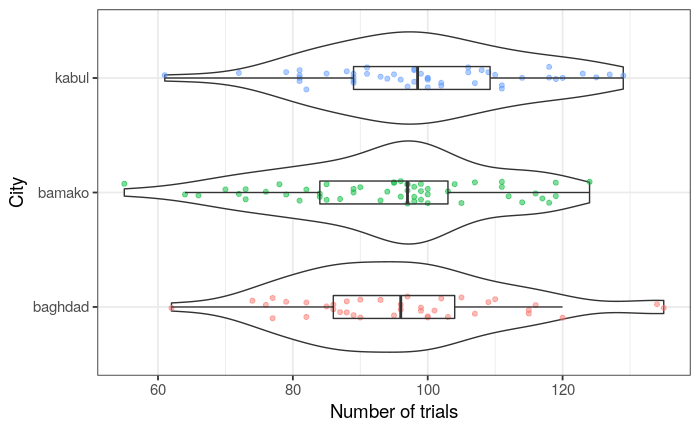

```r
ggplot(session_stats, aes(x = city, y = n_trials)) +
  geom_violin() +
  geom_jitter(height = 0, width = 0.1, alpha = 0.5, aes(colour = city)) +
  geom_boxplot(width = 0.2, fill = NA, outlier.shape = NA) +
  guides(colour = FALSE) +
  labs(x = "City",
       y = "Number of trials") +
  coord_flip()
```

The number of trials seems like it may have increased slightly from session 2 (pre-march) to session 3 (post-march).

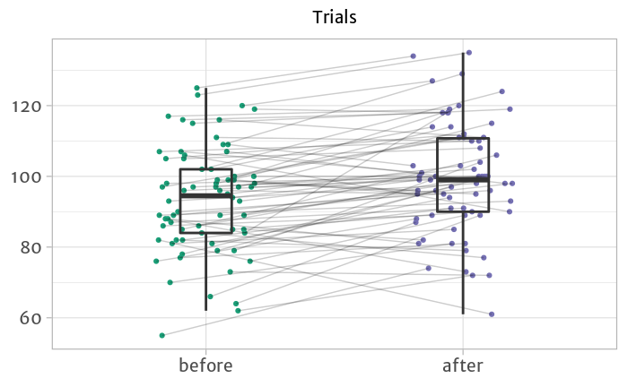

```r
ggplot(session_stats, aes(x = list, y = n_trials)) +
  geom_violin(colour = NA, fill = NA) +
  geom_point(aes(x = list_jittered, colour = list)) +
  geom_line(aes(x = list_jittered, group = subject), alpha = 0.2) +
  geom_boxplot(width = 0.2, fill = NA, outlier.shape = NA, lwd = 1) +
  guides(colour = FALSE) +
  scale_colour_manual(values = colours_custom) +
  labs(x = NULL, y = NULL, title = "Trials") +
  theme_poster

ggsave("../output/num_trials.pdf", device = "pdf", width = 3, height = 3)
```

Is there a within-subject increase in the number of trials?

Including a random intercept for city results in a singular fit:

```r
m_ntrials <- lmer(n_trials ~ list + (1 | subject) + (1 | city), data = session_stats)
```

```
boundary (singular) fit: see ?isSingular
```

```r
summary(m_ntrials)
```

```
Linear mixed model fit by REML ['lmerMod']
Formula: n_trials ~ list + (1 | subject) + (1 | city)
   Data: session_stats

REML criterion at convergence: 1089.4

Scaled residuals:
     Min       1Q   Median       3Q      Max
-2.30825 -0.46241  0.00166  0.48978  2.13990

Random effects:
 Groups   Name        Variance Std.Dev.
 subject  (Intercept) 178.00   13.34
 city     (Intercept)   0.00    0.00
 Residual              53.29    7.30
Number of obs: 140, groups:  subject, 70; city, 3

Fixed effects:
            Estimate Std. Error t value
(Intercept)   93.300      1.818  51.328
listafter      6.214      1.234   5.036

Correlation of Fixed Effects:
          (Intr)
listafter -0.339
convergence code: 0
boundary (singular) fit: see ?isSingular
```

Without random intercept for city:

```r
m_ntrials2 <- lmer(n_trials ~ list + (1 | subject), data = session_stats)

summary(m_ntrials2)
```

```
Linear mixed model fit by REML ['lmerMod']
Formula: n_trials ~ list + (1 | subject)
   Data: session_stats

REML criterion at convergence: 1089.4

Scaled residuals:
     Min       1Q   Median       3Q      Max
-2.30825 -0.46241  0.00166  0.48978  2.13990

Random effects:
 Groups   Name        Variance Std.Dev.
 subject  (Intercept) 178.00   13.34
 Residual              53.29    7.30
Number of obs: 140, groups:  subject, 70

Fixed effects:
            Estimate Std. Error t value
(Intercept)   93.300      1.818  51.328
listafter      6.214      1.234   5.036

Correlation of Fixed Effects:
          (Intr)
listafter -0.339
```

Comparison to a model without an effect of session shows that we should include it:

```r
m_ntrials3 <- lmer(n_trials ~ (1 | subject), data = session_stats)

summary(m_ntrials3)
```

```
Linear mixed model fit by REML ['lmerMod']
Formula: n_trials ~ (1 | subject)
   Data: session_stats

REML criterion at convergence: 1113.6

Scaled residuals:
     Min       1Q   Median       3Q      Max
-2.00793 -0.46243  0.07392  0.47278  2.23956

Random effects:
 Groups   Name        Variance Std.Dev.
 subject  (Intercept) 168.73   12.990
 Residual              71.84    8.476
Number of obs: 140, groups:  subject, 70

Fixed effects:
            Estimate Std. Error t value
(Intercept)    96.41       1.71   56.38
```

```r
anova(m_ntrials2, m_ntrials3)
```

```
refitting model(s) with ML (instead of REML)
```

```
Data: session_stats
Models:
m_ntrials3: n_trials ~ (1 | subject)
m_ntrials2: n_trials ~ list + (1 | subject)
           Df    AIC    BIC  logLik deviance  Chisq Chi Df Pr(>Chisq)
m_ntrials3  3 1122.5 1131.3 -558.26   1116.5
m_ntrials2  4 1102.6 1114.4 -547.30   1094.6 21.914      1  2.852e-06 ***
---
Signif. codes:  0 ‘***’ 0.001 ‘**’ 0.01 ‘*’ 0.05 ‘.’ 0.1 ‘ ’ 1
```

This model shows that participants completed about 6 trials more in the post-march session than in the pre-march session.

## Number of distinct facts

The adaptive learning system only introduces a new fact when it thinks all current facts have sufficiently high activation to not be forgotten in the next 15 seconds. This means that the better a participant is at memorising, and/or the easier the material, the more distinct facts will be presented during a session.

The number of distinct facts seen by participants look similar across all three cities, though perhaps slightly lower for Baghdad.

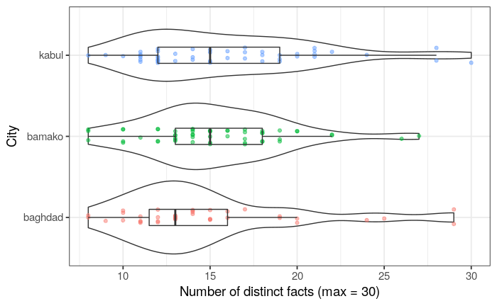

```r
ggplot(session_stats, aes(x = city, y = n_items)) +
  geom_violin() +
  geom_jitter(height = 0, width = 0.1, alpha = 0.5, aes(colour = city)) +
  geom_boxplot(width = 0.2, fill = NA, outlier.shape = NA) +
  guides(colour = FALSE) +
  labs(x = "City",
       y = "Number of distinct facts (max = 30)") +
  coord_flip()
```

The number of distinct facts also seems to increase slightly pre-march to post-march.

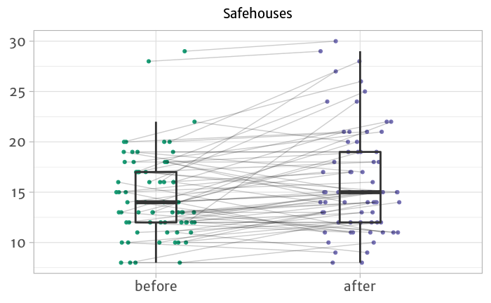

```r
ggplot(session_stats, aes(x = list, y = n_items)) +
  geom_violin(colour = NA, fill = NA) +
  geom_point(aes(x = list_jittered, colour = list)) +
  geom_line(aes(x = list_jittered, group = subject), alpha = 0.2) +
  geom_boxplot(width = 0.2, fill = NA, outlier.shape = NA, lwd = 1) +
  guides(colour = FALSE) +
  scale_colour_manual(values = colours_custom) +
  labs(x = NULL, y = NULL, title = "Safehouses") +
  theme_poster

ggsave("../output/num_facts.pdf", device = "pdf", width = 3, height = 3)
```

Including a random intercept for city results in a singular fit.

```r
m_nfacts <- lmer(n_items ~ list + (1 | subject) + (1 | city), data = session_stats)
```

```
boundary (singular) fit: see ?isSingular
```

```r
summary(m_nfacts)
```

```
Linear mixed model fit by REML ['lmerMod']
Formula: n_items ~ list + (1 | subject) + (1 | city)
   Data: session_stats

REML criterion at convergence: 774.6

Scaled residuals:
     Min       1Q   Median       3Q      Max
-1.96628 -0.49199 -0.05462  0.38763  2.33352

Random effects:
 Groups   Name        Variance Std.Dev.
 subject  (Intercept) 15.912   3.989
 city     (Intercept)  0.000   0.000
 Residual              6.011   2.452
Number of obs: 140, groups:  subject, 70; city, 3

Fixed effects:
            Estimate Std. Error t value
(Intercept)  14.5857     0.5596  26.064
listafter     1.5143     0.4144   3.654

Correlation of Fixed Effects:
          (Intr)
listafter -0.370
convergence code: 0
boundary (singular) fit: see ?isSingular
```

Without random intercept for city:

```r
m_nfacts2 <- lmer(n_items ~ list + (1 | subject), data = session_stats)

summary(m_nfacts2)
```

```
Linear mixed model fit by REML ['lmerMod']
Formula: n_items ~ list + (1 | subject)
   Data: session_stats

REML criterion at convergence: 774.6

Scaled residuals:
     Min       1Q   Median       3Q      Max
-1.96628 -0.49199 -0.05462  0.38763  2.33352

Random effects:
 Groups   Name        Variance Std.Dev.
 subject  (Intercept) 15.912   3.989
 Residual              6.011   2.452
Number of obs: 140, groups:  subject, 70

Fixed effects:
            Estimate Std. Error t value
(Intercept)  14.5857     0.5596  26.064
listafter     1.5143     0.4144   3.654

Correlation of Fixed Effects:
          (Intr)
listafter -0.370
```

Comparison to a model without an effect of session shows that we should include it:

```r
m_nfacts3 <- lmer(n_items ~ (1 | subject), data = session_stats)

summary(m_nfacts3)
```

```
Linear mixed model fit by REML ['lmerMod']
Formula: n_items ~ (1 | subject)
   Data: session_stats

REML criterion at convergence: 787

Scaled residuals:
     Min       1Q   Median       3Q      Max
-2.06955 -0.51610 -0.07592  0.38491  2.50104

Random effects:
 Groups   Name        Variance Std.Dev.
 subject  (Intercept) 15.381   3.922
 Residual              7.071   2.659
Number of obs: 140, groups:  subject, 70

Fixed effects:
            Estimate Std. Error t value
(Intercept)  15.3429     0.5198   29.51
```

```r
anova(m_nfacts2, m_nfacts3)
```

```
refitting model(s) with ML (instead of REML)
```

```
Data: session_stats
Models:
m_nfacts3: n_items ~ (1 | subject)
m_nfacts2: n_items ~ list + (1 | subject)
          Df    AIC    BIC  logLik deviance  Chisq Chi Df Pr(>Chisq)
m_nfacts3  3 793.54 802.37 -393.77   787.54
m_nfacts2  4 783.16 794.93 -387.58   775.16 12.383      1  0.0004333 ***
---
Signif. codes:  0 ‘***’ 0.001 ‘**’ 0.01 ‘*’ 0.05 ‘.’ 0.1 ‘ ’ 1
```

This model shows that participants encountered about 1.5 more facts in the post-march session than in the pre-march session.

## Response accuracy

All questions were 4-alternative multiple-choice with a single correct answer. Trials on which no response was made within 30 seconds of trial onset were marked as incorrect.

Response accuracy looks very similar across all three cities.

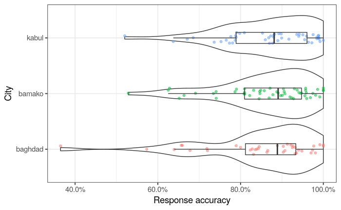

```r
ggplot(session_stats, aes(x = city, y = accuracy)) +
  geom_violin() +
  geom_jitter(height = 0, width = 0.1, alpha = 0.5, aes(colour = city)) +
  geom_boxplot(width = 0.2, fill = NA, outlier.shape = NA) +
  guides(colour = FALSE) +
  scale_y_continuous(labels = scales::percent_format()) +
  labs(x = "City",
       y = "Response accuracy") +
  coord_flip()
```

Response accuracy also seems to be the same before and after the speed march.

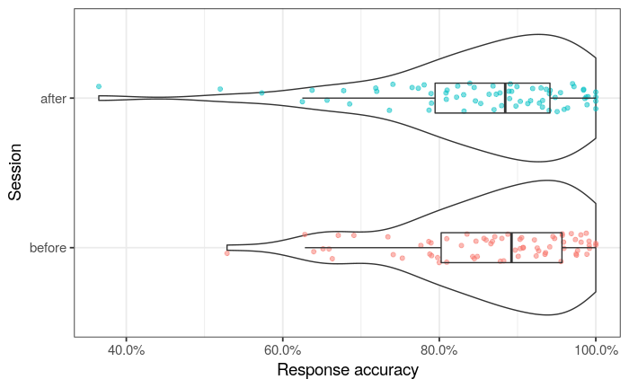

```r
ggplot(session_stats, aes(x = list, y = accuracy)) +
  geom_violin() +
  geom_jitter(height = 0, width = 0.1, alpha = 0.5, aes(colour = list)) +
  geom_boxplot(width = 0.2, fill = NA, outlier.shape = NA) +
  guides(colour = FALSE) +
  scale_y_continuous(labels = scales::percent_format()) +
  labs(x = "Session",
       y = "Response accuracy") +
  coord_flip()
```

Including a random intercept for city results in a failure to converge:

```r
m_acc <- lmer(accuracy ~ list + (1 | subject) + (1 | city), data = session_stats)
```

```
Model failed to converge with max|grad| = 0.0243543 (tol = 0.002, component 1)
```

```r
summary(m_acc)
```

```
Linear mixed model fit by REML ['lmerMod']
Formula: accuracy ~ list + (1 | subject) + (1 | city)
   Data: session_stats

REML criterion at convergence: -239.6

Scaled residuals:
    Min      1Q  Median      3Q     Max
-3.3749 -0.2779  0.1372  0.4361  2.1034

Random effects:
 Groups   Name        Variance  Std.Dev.
 subject  (Intercept) 9.653e-03 0.0982496
 city     (Intercept) 1.223e-08 0.0001106
 Residual             4.032e-03 0.0634982
Number of obs: 140, groups:  subject, 70; city, 3

Fixed effects:
            Estimate Std. Error t value
(Intercept)  0.86717    0.01398  62.019
listafter   -0.01251    0.01073  -1.166

Correlation of Fixed Effects:
          (Intr)
listafter -0.384
convergence code: 0
Model failed to converge with max|grad| = 0.0243543 (tol = 0.002, component 1)
```

Without random intercept for city:

```r
m_acc2 <- lmer(accuracy ~ list + (1 | subject), data = session_stats)

summary(m_acc2)
```

```
Linear mixed model fit by REML ['lmerMod']
Formula: accuracy ~ list + (1 | subject)
   Data: session_stats

REML criterion at convergence: -239.6

Scaled residuals:
    Min      1Q  Median      3Q     Max
-3.3747 -0.2784  0.1374  0.4355  2.1056

Random effects:
 Groups   Name        Variance Std.Dev.
 subject  (Intercept) 0.009681 0.09839
 Residual             0.004024 0.06343
Number of obs: 140, groups:  subject, 70

Fixed effects:
            Estimate Std. Error t value
(Intercept)  0.86717    0.01399  61.974
listafter   -0.01251    0.01072  -1.167

Correlation of Fixed Effects:
          (Intr)
listafter -0.383
```

Comparison to a model without an effect of session shows that we don’t need to include it:

```r
m_acc3 <- lmer(accuracy ~ (1 | subject), data = session_stats)

summary(m_acc3)
```

```
Linear mixed model fit by REML ['lmerMod']
Formula: accuracy ~ (1 | subject)
   Data: session_stats

REML criterion at convergence: -245.5

Scaled residuals:
    Min      1Q  Median      3Q     Max
-3.4690 -0.2554  0.1025  0.4537  2.0018

Random effects:
 Groups   Name        Variance Std.Dev.
 subject  (Intercept) 0.009671 0.09834
 Residual             0.004044 0.06360
Number of obs: 140, groups:  subject, 70

Fixed effects:
            Estimate Std. Error t value
(Intercept)  0.86091    0.01292   66.61
```

```r
anova(m_acc2, m_acc3)
```

```
refitting model(s) with ML (instead of REML)
```

```
Data: session_stats
Models:
m_acc3: accuracy ~ (1 | subject)
m_acc2: accuracy ~ list + (1 | subject)
       Df     AIC     BIC logLik deviance  Chisq Chi Df Pr(>Chisq)
m_acc3  3 -246.32 -237.50 126.16  -252.32
m_acc2  4 -245.69 -233.93 126.85  -253.69 1.3676      1     0.2422
```

In conclusion, there appears to be no difference between the pre-march learning session and the post-march session in terms of overall response accuracy.

## Response time

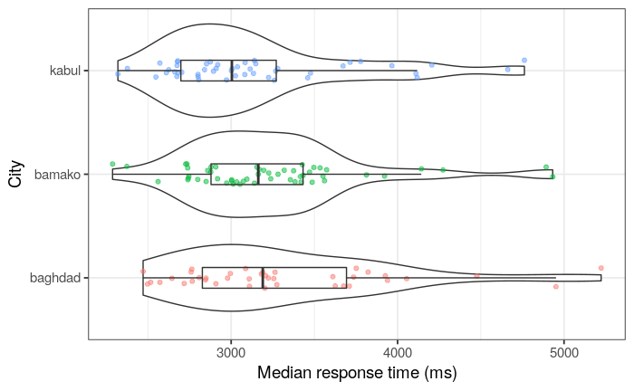

```r
ggplot(session_stats, aes(x = city, y = rt)) +
  geom_violin() +
  geom_jitter(height = 0, width = 0.1, alpha = 0.5, aes(colour = city)) +
  geom_boxplot(width = 0.2, fill = NA, outlier.shape = NA) +
  guides(colour = FALSE) +
  labs(x = "City",
       y = "Median response time (ms)") +
  coord_flip()
```

Response time does seem to decrease after the speed march.

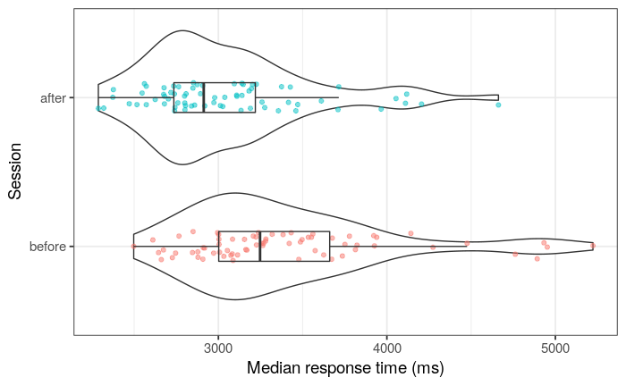

```r
ggplot(session_stats, aes(x = list, y = rt)) +
  geom_violin() +
  geom_jitter(height = 0, width = 0.1, alpha = 0.5, aes(colour = list)) +
  geom_boxplot(width = 0.2, fill = NA, outlier.shape = NA) +
  guides(colour = FALSE) +
  labs(x = "Session",
       y = "Median response time (ms)") +
  coord_flip()
```

Including a random intercept for city results in a failure to converge:

```r
m_rt <- lmer(rt ~ list + (1 | subject) + (1 | city), data = session_stats)
```

```
Model failed to converge with max|grad| = 0.00350319 (tol = 0.002, component 1)
```

```r
summary(m_rt)
```

```
Linear mixed model fit by REML ['lmerMod']
Formula: rt ~ list + (1 | subject) + (1 | city)
   Data: session_stats

REML criterion at convergence: 2112.8

Scaled residuals:
    Min      1Q  Median      3Q     Max
-1.9438 -0.5287 -0.1101  0.3595  2.9691

Random effects:
 Groups   Name        Variance  Std.Dev.
 subject  (Intercept) 165227.26 406.5
 city     (Intercept)      3.61   1.9
 Residual             130662.92 361.5
Number of obs: 140, groups:  subject, 70; city, 3

Fixed effects:
            Estimate Std. Error t value
(Intercept)  3390.14      65.03  52.136
listafter    -348.22      61.10  -5.699

Correlation of Fixed Effects:
          (Intr)
listafter -0.470
convergence code: 0
Model failed to converge with max|grad| = 0.00350319 (tol = 0.002, component 1)
```

Without random intercept for city:

```r
m_rt2 <- lmer(rt ~ list + (1 | subject), data = session_stats)

summary(m_rt2)
```

```
Linear mixed model fit by REML ['lmerMod']
Formula: rt ~ list + (1 | subject)
   Data: session_stats

REML criterion at convergence: 2112.8

Scaled residuals:
    Min      1Q  Median      3Q     Max
-1.9440 -0.5285 -0.1100  0.3592  2.9690

Random effects:
 Groups   Name        Variance Std.Dev.
 subject  (Intercept) 165279   406.5
 Residual             130643   361.4
Number of obs: 140, groups:  subject, 70

Fixed effects:
            Estimate Std. Error t value
(Intercept)  3390.13      65.02  52.141
listafter    -348.21      61.10  -5.699

Correlation of Fixed Effects:
          (Intr)
listafter -0.470
```

Comparison to a model without an effect of session shows that we should include it:

```r
m_rt3 <- lmer(rt ~ (1 | subject), data = session_stats)

summary(m_rt3)
```

```
Linear mixed model fit by REML ['lmerMod']
Formula: rt ~ (1 | subject)
   Data: session_stats

REML criterion at convergence: 2149.9

Scaled residuals:
    Min      1Q  Median      3Q     Max
-1.8231 -0.5135 -0.1441  0.3378  3.0801

Random effects:
 Groups   Name        Variance Std.Dev.
 subject  (Intercept) 135900   368.6
 Residual             189401   435.2
Number of obs: 140, groups:  subject, 70

Fixed effects:
            Estimate Std. Error t value
(Intercept)   3216.0       57.4   56.03
```

```r
anova(m_rt2, m_rt3)
```

```
refitting model(s) with ML (instead of REML)
```

```
Data: session_stats
Models:
m_rt3: rt ~ (1 | subject)
m_rt2: rt ~ list + (1 | subject)
      Df    AIC    BIC  logLik deviance  Chisq Chi Df Pr(>Chisq)
m_rt3  3 2165.8 2174.7 -1079.9   2159.8
m_rt2  4 2140.8 2152.6 -1066.4   2132.8 27.005      1  2.029e-07 ***
---
Signif. codes:  0 ‘***’ 0.001 ‘**’ 0.01 ‘*’ 0.05 ‘.’ 0.1 ‘ ’ 1
```

This model shows that responses were about 350 ms faster after the speed march compared to before.

# Rate of forgetting

```r
source(file.path("99-model_funs.R"))

act <- d %>%
  transmute(subject,
            city,
            fact_id = id,
            text = "",
            start_time,
            rt,
            correct,
            threshold = -0.8)
```

Calculate final rate of forgetting estimates for every user/fact pair:

```r
act_by_subj_and_fact <- split(act, list(act$subject, act$fact_id)) %>%
  keep(~ nrow(.x) > 0)

alpha <- future_map_dfr(act_by_subj_and_fact, function(x) {
  x %>%
    summarise(subject = subject[1],
              city = city[1],
              fact_id = fact_id[1],
              reps = n(),
              final_alpha = calculate_alpha(max(start_time) + 1, fact_id, 0.3, x))
})
```

Compare rate of forgetting measured in the pre-march session to rate of forgetting measured in the post-march session.

```r
pre_post <- distinct(d, subject, list, city) %>%
  left_join(alpha, by = c("subject", "city")) %>%
  filter(reps >= 3) %>%
  mutate_if(is.character, as.factor)
```

```r
alpha_by_list <- pre_post %>%
  group_by(subject, list, city) %>%
  summarise(mean_alpha = mean(final_alpha)) %>%
  select(-city) %>%
  spread(list, mean_alpha)
```

The plot below compares each subject’s pre-march rate of forgetting to their post-march rate of forgetting. There is quite a strong correlation between the two measurements. There does not appear to be a strong positive or negative effect of the speed march.

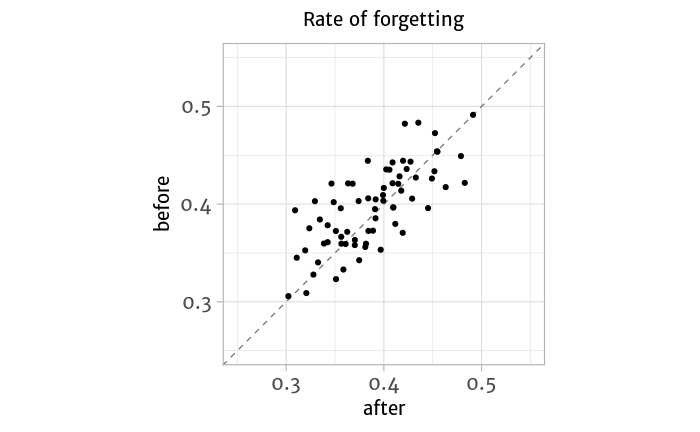

```r
corr_pre_post <- with(alpha_by_list, cor.test(before, after, method = "pearson"))

lims <- c(0.25, 0.55)

ggplot(alpha_by_list, aes(x = after, y = before)) +
  geom_abline(lty = 2, colour = "grey50") +
  geom_point() +
  coord_fixed() +
  xlim(0.25, 0.55) +
  ylim(0.25, 0.55) +
  labs(title = "Rate of forgetting") +
  theme_poster

ggsave("../output/rof.pdf", device = "pdf", width = 3, height = 3)
```

Make the plot shown on the poster:

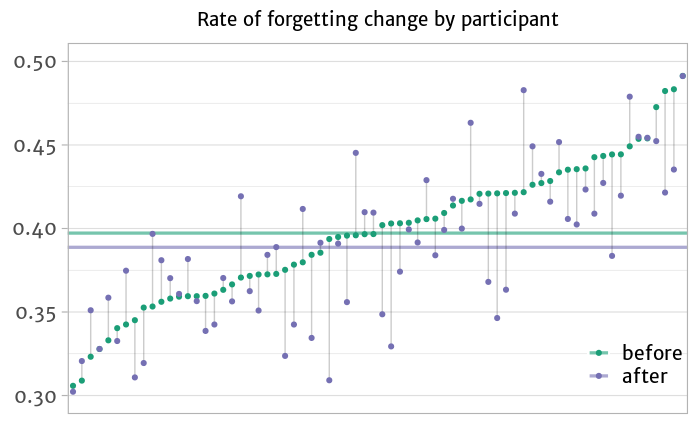

```r
alpha_by_list_long <- alpha_by_list %>%
  pivot_longer(before:after, names_to = "list", values_to = "rof") %>%
  mutate(list = fct_rev(list))

alpha_by_list_avg <- alpha_by_list_long %>%
  group_by(list) %>%
  summarise(rof = mean(rof))


ggplot(alpha_by_list, aes(x = reorder(subject, before), y = before)) +
  geom_hline(data = alpha_by_list_avg, aes(yintercept = rof, colour = list), lwd = 1.15, alpha = 0.6) +
  geom_linerange(aes(ymin = before, ymax = after), alpha = 0.2) +
  geom_point(data = alpha_by_list_long, aes(x = subject, y = rof, colour = list, fill = list)) +
  scale_colour_manual(values = colours_custom) +
  scale_fill_manual(values = colours_custom) +
  ylim(0.299, 0.501) +
  labs(x = NULL,
       y = NULL,
       colour = NULL,
       fill = NULL,
       title = "Rate of forgetting change by participant") +
  theme_poster +
  theme(legend.position = c(.915,0.15),
        axis.text.x = element_blank(),
        axis.ticks.x = element_blank(),
        panel.grid.major.x = element_blank())

ggsave("../output/rof_alt.pdf", device = "pdf", width = 7, height = 3.5)
```

A linear mixed-effects regression suggests that there is a very small effect of list on rate of forgetting when controlling for participants and items. (Using untransformed rates of forgetting results in non-normal residuals, so using log-transformed rate of forgetting instead.)

```r
pre_post$final_alpha_log <- log(pre_post$final_alpha)

m_prepost <- lmer(final_alpha_log ~ list + (1 | subject) + (1 | fact_id), data = pre_post)

m_prepost_null <- lmer(final_alpha_log ~ (1 | subject) + (1 | fact_id), data = pre_post)

anova(m_prepost, m_prepost_null)
```

```
refitting model(s) with ML (instead of REML)
```

```
Data: pre_post
Models:
m_prepost_null: final_alpha_log ~ (1 | subject) + (1 | fact_id)
m_prepost: final_alpha_log ~ list + (1 | subject) + (1 | fact_id)
               Df    AIC    BIC  logLik deviance  Chisq Chi Df Pr(>Chisq)
m_prepost_null  4 26.157 48.620 -9.0783   18.157
m_prepost       5 22.535 50.613 -6.2672   12.534 5.6221      1    0.01774 *
---
Signif. codes:  0 ‘***’ 0.001 ‘**’ 0.01 ‘*’ 0.05 ‘.’ 0.1 ‘ ’ 1
```

```r
summary(m_prepost)
```

```
Linear mixed model fit by REML ['lmerMod']
Formula: final_alpha_log ~ list + (1 | subject) + (1 | fact_id)
   Data: pre_post

REML criterion at convergence: 26.3

Scaled residuals:
    Min      1Q  Median      3Q     Max
-2.8194 -0.6463  0.0451  0.6690  3.4055

Random effects:
 Groups   Name        Variance Std.Dev.
 fact_id  (Intercept) 0.008043 0.08968
 subject  (Intercept) 0.008050 0.08972
 Residual             0.052174 0.22842
Number of obs: 2030, groups:  fact_id, 90; subject, 70

Fixed effects:
            Estimate Std. Error t value
(Intercept) -0.96579    0.01622 -59.541
listafter   -0.02496    0.01053  -2.372

Correlation of Fixed Effects:
          (Intr)
listafter -0.340
```

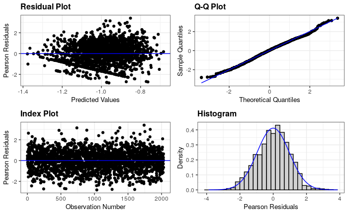

```r
resid_panel(m_prepost)
```

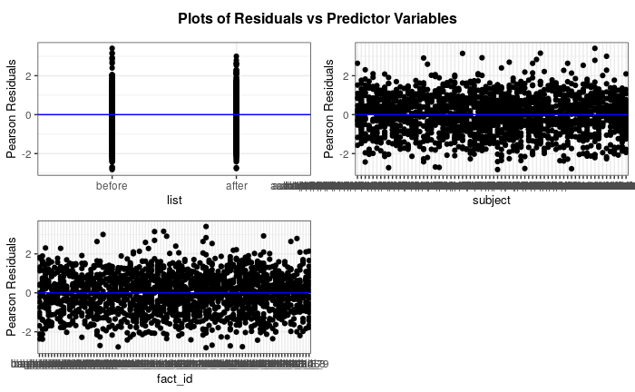

```r
resid_xpanel(m_prepost)
```

This model finds that post-march rate of forgetting is a bit lower than the pre-march estimate.

Model predictions (pre-march rate of forgetting, post-march rate of forgetting):

```r
exp(fixef(m_prepost)[1])
```

```
(Intercept)
  0.3806815
```

```r
exp(fixef(m_prepost)[1] + fixef(m_prepost)[2])
```

```
(Intercept)
  0.3712956
```

# Within-session trends

## Accuracy

How does accuracy develop within a session? The plot below shows mean response accuracy (+/- 1 SE) over the course of the session, calculated in 10-trial bins. Study trials are removed. Both sessions show a roughly similar shape: initially accuracy is really high (which is unsurprising: there are many immediate repetitions following study trials) but then it drops before slowly recovering. The drop in accuracy seems to be larger in the post-march session, which suggests that participants are less successful at creating a long-term memory representation.

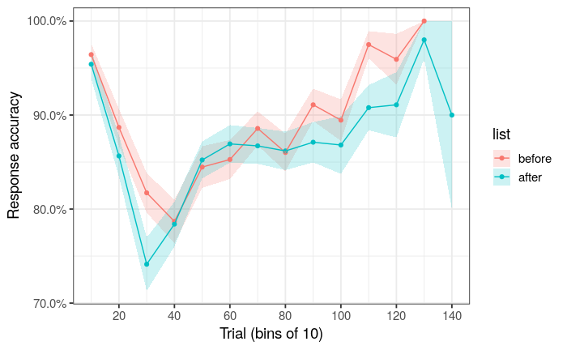

```r
binsize <- 10

d %>%
  mutate(part = cut(trial_index - 2, seq(0, max(trial_index) + 3, by = binsize), labels = F) * binsize) %>%
  filter(study == FALSE) %>%
  group_by(subject, list, part) %>%
  summarise(accuracy = mean(correct)) %>%
  group_by(list, part) %>%
  summarise(acc_se = sd(accuracy)/sqrt(n()),
            acc = mean(accuracy)) %>%
  ggplot(aes(x = part, y = acc, group = list, colour = list)) +
  geom_ribbon(aes(ymin = acc - acc_se, ymax = acc + acc_se, fill = list), alpha = 0.2, colour = NA) +
  geom_point() +
  geom_line() +
  scale_x_continuous(breaks = seq(0, 200, by = 20)) +
  scale_y_continuous(labels = scales::percent_format()) +
  labs(x = paste0("Trial (bins of ", binsize, ")"),
       y = "Response accuracy")
```

We can make the same plot but with the presentation count on the x-axis. A fact is generally not presented more than 10 times during a session:

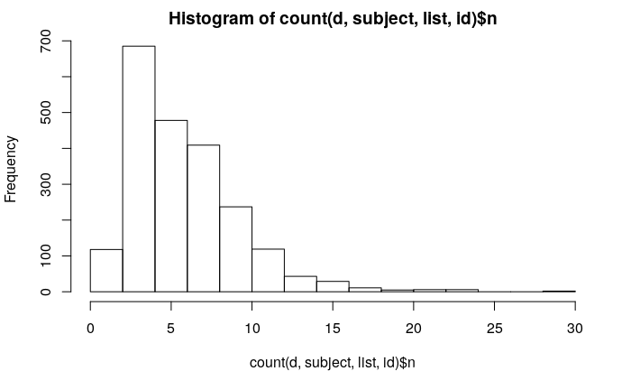

```r
hist(count(d, subject, list, id)$n, 20)
```

This plot indicates that response accuracy is a bit lower on the third presentation in the post-march session. The first presentation is always a study trial, and the second presentation typically comes directly after. The third presentation comes later and is therefore an indication of how well the short-term information has been consolidated in long term memory.

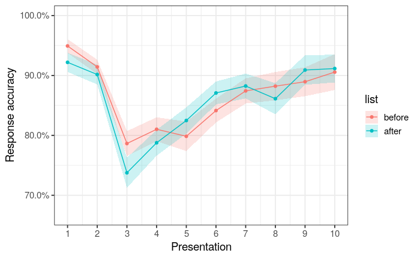

```r
d %>%
  group_by(subject, list, presentation) %>%
  summarise(accuracy = mean(correct)) %>%
  group_by(list, presentation) %>%
  summarise(acc_se = sd(accuracy)/sqrt(n()),
            acc = mean(accuracy)) %>%
  ggplot(aes(x = presentation, y = acc, group = list, colour = list)) +
  geom_ribbon(aes(ymin = acc - acc_se, ymax = acc + acc_se, fill = list), alpha = 0.2, colour = NA) +
  geom_point() +
  geom_line() +
  scale_x_continuous(limits = c(1, 10), breaks = 1:10) +
  scale_y_continuous(labels = scales::percent_format()) +
  labs(x = paste0("Presentation"),
       y = "Response accuracy")
```

We can also plot accuracy as a function of time to see if there is a difference.

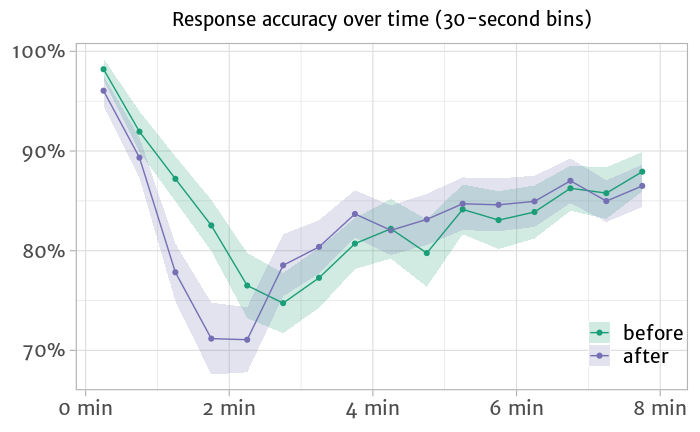

```r
binsize_time <- 30

d %>%
  group_by(subject, list) %>%
  mutate(time = (start_time - min(start_time))/1000) %>%
  ungroup() %>%
  mutate(part = cut(time, seq(0, max(time) + 10, by = binsize_time), labels = F, include.lowest = TRUE) * binsize_time) %>%
  group_by(subject, list, part) %>%
  summarise(accuracy = mean(correct)) %>%
  group_by(list, part) %>%
  summarise(acc_se = sd(accuracy)/sqrt(n()),
            acc = mean(accuracy)) %>%
  ggplot(aes(x = (part - binsize_time/2)/60, y = acc, group = list, colour = list)) +
  geom_ribbon(aes(ymin = acc - acc_se, ymax = acc + acc_se, fill = list), alpha = 0.2, colour = NA) +
  geom_point() +
  geom_line() +
  scale_x_continuous(labels = scales::unit_format(unit = "min")) +
  scale_y_continuous(labels = scales::percent_format(accuracy = 1)) +
  scale_colour_manual(values = colours_custom) +
  scale_fill_manual(values = colours_custom) +
  expand_limits(x = 8.0001) + # Avoid "8 min" label being cut off
  labs(x = NULL,
       y = NULL,
       title = "Response accuracy over time (30-second bins)",
       colour = NULL,
       fill = NULL) +
  theme_poster +
  theme(legend.position = c(.915,0.15))

ggsave("../output/acc_over_time.pdf", device = "pdf", width = 7, height = 3.5)
```

Let’s model this. There is clearly a strong non-linear effect of time, which means that we’ll have to use GAMs.

```r
d_gam <- d %>%
  group_by(subject, list, id) %>%
  mutate(time_since_introduced = (start_time - min(start_time))/1000) %>%
  ungroup() %>%
  group_by(subject, list) %>%
  mutate(time = (start_time - min(start_time))/1000) %>%
  ungroup() %>%
  mutate_if(is.character, as.factor)
```

Fit a time smooth for each list.

```r
gam_acc0 <- bam(correct ~ list + s(time, by = list) + s(subject, bs = "re") + s(id, bs = "re"),
               family = binomial,
               data = d_gam)

summary(gam_acc0)
```

```
Family: binomial
Link function: logit

Formula:
correct ~ list + s(time, by = list) + s(subject, bs = "re") +
    s(id, bs = "re")

Parametric coefficients:
            Estimate Std. Error z value Pr(>|z|)
(Intercept)  2.35764    0.13684  17.230  < 2e-16 ***
listafter   -0.17287    0.06027  -2.868  0.00413 **
---
Signif. codes:  0 ‘***’ 0.001 ‘**’ 0.01 ‘*’ 0.05 ‘.’ 0.1 ‘ ’ 1

Approximate significance of smooth terms:
                      edf Ref.df  Chi.sq  p-value
s(time):listbefore  6.113  7.271  124.94  < 2e-16 ***
s(time):listafter   7.213  8.238  160.37  < 2e-16 ***
s(subject)         64.364 69.000 1028.87  < 2e-16 ***
s(id)              32.320 89.000   74.48 0.000828 ***
---
Signif. codes:  0 ‘***’ 0.001 ‘**’ 0.01 ‘*’ 0.05 ‘.’ 0.1 ‘ ’ 1

R-sq.(adj) =  0.129   Deviance explained = 16.1%
fREML =  18798  Scale est. = 1         n = 13497
```

This model already does OK, but it does not incorporate information about the learner’s familiarity with each specific item. To address this, fit a model with an additional smooth for the time elapsed since the item was introduced, separately for each list.

```r
gam_acc1 <- bam(correct ~ list + s(time, by = list) + s(time_since_introduced, by = list) + s(subject, bs = "re") + s(id, bs = "re"),
               family = binomial,
               data = d_gam)

summary(gam_acc1)
```

```
Family: binomial
Link function: logit

Formula:
correct ~ list + s(time, by = list) + s(time_since_introduced,
    by = list) + s(subject, bs = "re") + s(id, bs = "re")

Parametric coefficients:
            Estimate Std. Error z value Pr(>|z|)
(Intercept)  2.40122    0.14108  17.020  < 2e-16 ***
listafter   -0.18472    0.06149  -3.004  0.00266 **
---
Signif. codes:  0 ‘***’ 0.001 ‘**’ 0.01 ‘*’ 0.05 ‘.’ 0.1 ‘ ’ 1

Approximate significance of smooth terms:
                                       edf Ref.df  Chi.sq  p-value
s(time):listbefore                   4.963  6.105   42.20 2.05e-07 ***
s(time):listafter                    6.349  7.519   55.86 2.35e-09 ***
s(time_since_introduced):listbefore  6.766  7.828   89.95 1.83e-15 ***
s(time_since_introduced):listafter   7.030  8.047   85.04 5.12e-15 ***
s(subject)                          64.550 69.000 1040.44  < 2e-16 ***
s(id)                               34.334 89.000   82.92 0.000329 ***
---
Signif. codes:  0 ‘***’ 0.001 ‘**’ 0.01 ‘*’ 0.05 ‘.’ 0.1 ‘ ’ 1

R-sq.(adj) =  0.143   Deviance explained = 17.9%
fREML =  18713  Scale est. = 1         n = 13497
```

The second model is indeed preferred:

```r
compareML(gam_acc0, gam_acc1)
```

```
gam_acc0: correct ~ list + s(time, by = list) + s(subject, bs = "re") +
    s(id, bs = "re")

gam_acc1: correct ~ list + s(time, by = list) + s(time_since_introduced,
    by = list) + s(subject, bs = "re") + s(id, bs = "re")

Chi-square test of fREML scores
-----
```

| Model | Score | Edf | Difference | Df | p.value | Sig. |
| --- | --- | --- | --- | --- | --- | --- |
| gam_acc0 | 18798.34 | 8 |  |  |  |  |
| gam_acc1 | 18713.40 | 12 | 84.937 | 4.000 | < 2e-16 | *** |

```
AIC difference: 153.11, model gam_acc1 has lower AIC.
```

Also fit a model with only the time-since-introduced, for comparison.

```r
gam_acc2 <- bam(correct ~ list + s(time_since_introduced, by = list) + s(subject, bs = "re") + s(id, bs = "re"),
               family = binomial,
               data = d_gam)

summary(gam_acc2)
```

```
Family: binomial
Link function: logit

Formula:
correct ~ list + s(time_since_introduced, by = list) + s(subject,
    bs = "re") + s(id, bs = "re")

Parametric coefficients:
            Estimate Std. Error z value Pr(>|z|)
(Intercept)  2.36132    0.13764  17.156  < 2e-16 ***
listafter   -0.17672    0.05921  -2.984  0.00284 **
---
Signif. codes:  0 ‘***’ 0.001 ‘**’ 0.01 ‘*’ 0.05 ‘.’ 0.1 ‘ ’ 1

Approximate significance of smooth terms:
                                       edf Ref.df Chi.sq  p-value
s(time_since_introduced):listbefore  6.835  7.883  188.7  < 2e-16 ***
s(time_since_introduced):listafter   7.384  8.321  208.2  < 2e-16 ***
s(subject)                          64.399 69.000 1031.5  < 2e-16 ***
s(id)                               33.621 89.000   79.2 0.000607 ***
---
Signif. codes:  0 ‘***’ 0.001 ‘**’ 0.01 ‘*’ 0.05 ‘.’ 0.1 ‘ ’ 1

R-sq.(adj) =  0.134   Deviance explained = 16.7%
fREML =  18705  Scale est. = 1         n = 13497
```

And fit a model with a smooth for time plus a smooth for presentation count rather than time-since-introduced:

```r
gam_acc3 <- bam(correct ~ list + s(time, by = list) + s(presentation, by = list) + s(subject, bs = "re") + s(id, bs = "re"),
               family = binomial,
               data = d_gam)

summary(gam_acc3)
```

```
Family: binomial
Link function: logit

Formula:
correct ~ list + s(time, by = list) + s(presentation, by = list) +
    s(subject, bs = "re") + s(id, bs = "re")

Parametric coefficients:
            Estimate Std. Error z value Pr(>|z|)
(Intercept)  2.44988    0.14437  16.970  < 2e-16 ***
listafter   -0.22470    0.06696  -3.356 0.000792 ***
---
Signif. codes:  0 ‘***’ 0.001 ‘**’ 0.01 ‘*’ 0.05 ‘.’ 0.1 ‘ ’ 1

Approximate significance of smooth terms:
                              edf Ref.df  Chi.sq  p-value
s(time):listbefore          5.607  6.768   51.60 7.20e-09 ***
s(time):listafter           7.011  8.084   76.56 2.88e-13 ***
s(presentation):listbefore  4.408  4.991   88.26  < 2e-16 ***
s(presentation):listafter   5.175  5.826   80.07 4.26e-15 ***
s(subject)                 64.577 69.000 1058.88  < 2e-16 ***
s(id)                      39.405 89.000  105.01 5.86e-05 ***
---
Signif. codes:  0 ‘***’ 0.001 ‘**’ 0.01 ‘*’ 0.05 ‘.’ 0.1 ‘ ’ 1

R-sq.(adj) =  0.144   Deviance explained = 18.2%
fREML =  18612  Scale est. = 1         n = 13497
```

The model with a smooth for time and an additional smooth for the presentation count performs best:

```r
compareML(gam_acc1, gam_acc2)
```

```
gam_acc1: correct ~ list + s(time, by = list) + s(time_since_introduced,
    by = list) + s(subject, bs = "re") + s(id, bs = "re")

gam_acc2: correct ~ list + s(time_since_introduced, by = list) + s(subject,
    bs = "re") + s(id, bs = "re")

Model gam_acc2 preferred: lower fREML score (8.633), and lower df (4.000).
-----
```

| Model | Score | Edf | Difference | Df |
| --- | --- | --- | --- | --- |
| gam_acc1 | 18713.40 | 12 |  |  |
| gam_acc2 | 18704.77 | 8 | -8.633 | 4.000 |

```
AIC difference: -97.58, model gam_acc1 has lower AIC.
```

```r
compareML(gam_acc2, gam_acc3)
```

```
gam_acc2: correct ~ list + s(time_since_introduced, by = list) + s(subject,
    bs = "re") + s(id, bs = "re")

gam_acc3: correct ~ list + s(time, by = list) + s(presentation, by = list) +
    s(subject, bs = "re") + s(id, bs = "re")

Chi-square test of fREML scores
-----
```

| Model | Score | Edf | Difference | Df | p.value | Sig. |
| --- | --- | --- | --- | --- | --- | --- |
| gam_acc2 | 18704.77 | 8 |  |  |  |  |
| gam_acc3 | 18612.31 | 12 | 92.460 | 4.000 | < 2e-16 | *** |

```
AIC difference: 124.07, model gam_acc3 has lower AIC.
```

A model that combines all three smooths is overkill:

```r
gam_acc4 <- bam(correct ~ list + s(time, by = list) + s(time_since_introduced, by = list) + s(presentation, by = list) + s(subject, bs = "re") + s(id, bs = "re"),
               family = binomial,
               data = d_gam)

summary(gam_acc4)
```

```
Family: binomial
Link function: logit

Formula:
correct ~ list + s(time, by = list) + s(time_since_introduced,
    by = list) + s(presentation, by = list) + s(subject, bs = "re") +
    s(id, bs = "re")

Parametric coefficients:
            Estimate Std. Error z value Pr(>|z|)
(Intercept)  2.44677    0.14414  16.974  < 2e-16 ***
listafter   -0.21595    0.06271  -3.443 0.000574 ***
---
Signif. codes:  0 ‘***’ 0.001 ‘**’ 0.01 ‘*’ 0.05 ‘.’ 0.1 ‘ ’ 1

Approximate significance of smooth terms:
                                       edf Ref.df  Chi.sq  p-value
s(time):listbefore                   4.991  6.139   42.17 2.19e-07 ***
s(time):listafter                    6.410  7.575   57.61 1.13e-09 ***
s(time_since_introduced):listbefore  7.115  8.115   81.12 4.31e-14 ***
s(time_since_introduced):listafter   7.113  8.112   44.48 4.98e-07 ***
s(presentation):listbefore           1.191  1.361   18.28 3.35e-05 ***
s(presentation):listafter            3.628  4.491   31.81 5.18e-06 ***
s(subject)                          64.647 69.000 1066.81  < 2e-16 ***
s(id)                               40.362 89.000  110.12 3.60e-05 ***
---
Signif. codes:  0 ‘***’ 0.001 ‘**’ 0.01 ‘*’ 0.05 ‘.’ 0.1 ‘ ’ 1

R-sq.(adj) =   0.15   Deviance explained = 18.7%
fREML =  18677  Scale est. = 1         n = 13497
```

```r
compareML(gam_acc3, gam_acc4)
```

```
gam_acc3: correct ~ list + s(time, by = list) + s(presentation, by = list) +
    s(subject, bs = "re") + s(id, bs = "re")

gam_acc4: correct ~ list + s(time, by = list) + s(time_since_introduced,
    by = list) + s(presentation, by = list) + s(subject, bs = "re") +
    s(id, bs = "re")

Model gam_acc3 preferred: lower fREML score (64.318), and lower df (4.000).
-----
```

| Model | Score | Edf | Difference | Df |
| --- | --- | --- | --- | --- |
| gam_acc4 | 18676.63 | 16 |  |  |
| gam_acc3 | 18612.31 | 12 | 64.318 | -4.000 |

```
AIC difference: 33.61, model gam_acc4 has lower AIC.
```

Adding a random factor smooth over time instead of a random intercept for subjects improves the model:

```r
gam_acc5 <- bam(correct ~ list + s(time, by = list) + s(presentation, by = list) + s(time, subject, bs = "fs", m = 1) + s(id, bs = "re"),
               family = binomial,
               data = d_gam,
               nthreads = 7)

compareML(gam_acc3, gam_acc5)
```

```
gam_acc3: correct ~ list + s(time, by = list) + s(presentation, by = list) +
    s(subject, bs = "re") + s(id, bs = "re")

gam_acc5: correct ~ list + s(time, by = list) + s(presentation, by = list) +
    s(time, subject, bs = "fs", m = 1) + s(id, bs = "re")

Chi-square test of fREML scores
-----
```

| Model | Score | Edf | Difference | Df | p.value | Sig. |
| --- | --- | --- | --- | --- | --- | --- |
| gam_acc3 | 18612.31 | 12 |  |  |  |  |
| gam_acc5 | 18289.27 | 13 | 323.038 | 1.000 | < 2e-16 | *** |

```
AIC difference: 97.60, model gam_acc5 has lower AIC.
```

Should we add another random factor smooth over presentation? Yes.

```r
gam_acc6 <- bam(correct ~ list + s(time, by = list) + s(presentation, by = list) + s(time, subject, bs = "fs", m = 1) + s(presentation, subject, bs = "fs", m = 1) + s(id, bs = "re"),
                family = binomial,
                data = d_gam,
                nthreads = 7)
```

```
model has repeated 1-d smooths of same variable.
```

```r
compareML(gam_acc5, gam_acc6)
```

```
gam_acc5: correct ~ list + s(time, by = list) + s(presentation, by = list) +
    s(time, subject, bs = "fs", m = 1) + s(id, bs = "re")

gam_acc6: correct ~ list + s(time, by = list) + s(presentation, by = list) +
    s(time, subject, bs = "fs", m = 1) + s(presentation, subject,
    bs = "fs", m = 1) + s(id, bs = "re")

Chi-square test of fREML scores
-----
```

| Model | Score | Edf | Difference | Df | p.value | Sig. |
| --- | --- | --- | --- | --- | --- | --- |
| gam_acc5 | 18289.27 | 13 |  |  |  |  |
| gam_acc6 | 18212.11 | 15 | 77.158 | 2.000 | < 2e-16 | *** |

```
AIC difference: 44.80, model gam_acc6 has lower AIC.
```

Also adding these random factor smooths for facts improves the model very slightly, but it takes forever to run and does not really make sense conceptually, so skip for now.

```r
# gam_acc7 <- bam(correct ~ list + s(time, by = list) + s(presentation, by = list) + s(time, subject, bs = "fs", m = 1) + s(presentation, subject, bs = "fs", m = 1) + s(time, id, bs = "fs", m = 1) + s(presentation, id, bs = "fs", m = 1),
#                 family = binomial,
#                 data = d_gam,
#                 nthreads = 7)
#
# compareML(gam_acc6, gam_acc7)
```

Best model:

```r
summary(gam_acc6)
```

```
Family: binomial
Link function: logit

Formula:
correct ~ list + s(time, by = list) + s(presentation, by = list) +
    s(time, subject, bs = "fs", m = 1) + s(presentation, subject,
    bs = "fs", m = 1) + s(id, bs = "re")

Parametric coefficients:
            Estimate Std. Error z value Pr(>|z|)
(Intercept)  2.47911    0.15023  16.502  < 2e-16 ***
listafter   -0.23641    0.06836  -3.458 0.000544 ***
---
Signif. codes:  0 ‘***’ 0.001 ‘**’ 0.01 ‘*’ 0.05 ‘.’ 0.1 ‘ ’ 1

Approximate significance of smooth terms:
                              edf  Ref.df Chi.sq  p-value
s(time):listbefore          5.580   6.715  46.39 7.24e-08 ***
s(time):listafter           6.989   8.044  72.96 1.40e-12 ***
s(presentation):listbefore  4.355   4.937  72.68 4.89e-14 ***
s(presentation):listafter   5.089   5.713  65.47 3.96e-12 ***
s(time,subject)            93.865 629.000 143.79  < 2e-16 ***
s(presentation,subject)    95.770 625.000 205.20  < 2e-16 ***
s(id)                      39.852  89.000  76.01 5.45e-07 ***
---
Signif. codes:  0 ‘***’ 0.001 ‘**’ 0.01 ‘*’ 0.05 ‘.’ 0.1 ‘ ’ 1

R-sq.(adj) =  0.174   Deviance explained = 21.9%
fREML =  18212  Scale est. = 1         n = 13497
```

```
Summary:
    * list : factor; set to the value(s): after.
    * time : numeric predictor; with 30 values ranging from 0.000000 to 479.993000.
    * presentation : numeric predictor; with 30 values ranging from 0.000000 to 15.000000.
    * subject : factor; set to the value(s): auth0|5d72225c50336a0e1a74f9ed. (Might be canceled as random effect, check below.)
    * id : factor; set to the value(s): kabul_22. (Might be canceled as random effect, check below.)
    * NOTE : The following random effects columns are canceled: s(time,subject),s(presentation,subject),s(id)
```

```
data length [31] is not a sub-multiple or multiple of the number of rows [30]
```

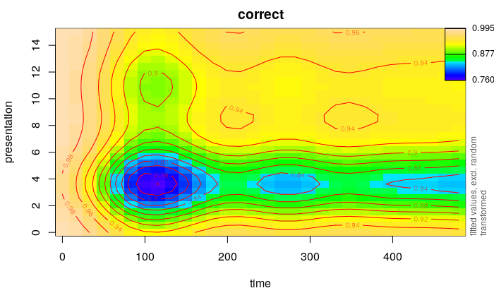

```r
fvisgam(gam_acc6, view = c("time", "presentation"), rm.ranef = TRUE, transform = plogis, ylim = c(0, 15))
```

The plot below shows the smooths over time for both sessions.

```
Summary:
    * list : factor; set to the value(s): after, before.
    * time : numeric predictor; with 30 values ranging from 0.000000 to 479.993000.
    * presentation : numeric predictor; set to the value(s): 4.
    * subject : factor; set to the value(s): auth0|5d72225c50336a0e1a74f9ed. (Might be canceled as random effect, check below.)
    * id : factor; set to the value(s): kabul_22. (Might be canceled as random effect, check below.)
    * NOTE : The following random effects columns are canceled: s(time,subject),s(presentation,subject),s(id)
```

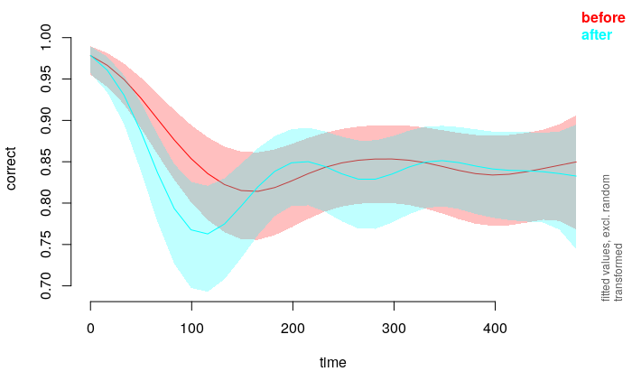

```r
plot_smooth(gam_acc6, view = "time", plot_all = "list", rm.ranef = TRUE, transform = plogis)
```

There is a significant difference between pre-march and post-march accuracy at the start of the session:

```
Summary:
    * time : numeric predictor; with 100 values ranging from 0.000000 to 479.993000.
    * presentation : numeric predictor; set to the value(s): 4.
    * subject : factor; set to the value(s): auth0|5d72225c50336a0e1a74f9ed. (Might be canceled as random effect, check below.)
    * id : factor; set to the value(s): kabul_22. (Might be canceled as random effect, check below.)
    * NOTE : The following random effects columns are canceled: s(time,subject),s(presentation,subject),s(id)


time window(s) of significant difference(s):
    48.484141 - 130.907182
```

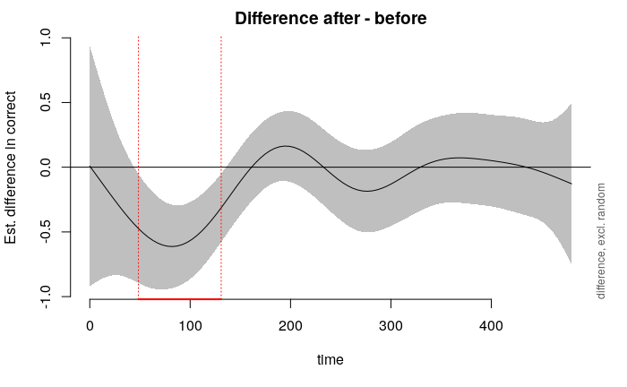

```r
plot_diff(gam_acc6, view = "time", comp = list(list = c("after", "before")), rm.ranef = TRUE)
```

## Response time

We can do a similar analysis for response time. The plot below shows average response time over the course of the session (we calculate the median RT per participant and then take the mean across participants). Study trials and trials with incorrect/missing responses are removed. The plot suggests that participants respond faster on correct trials after the speed march than before.

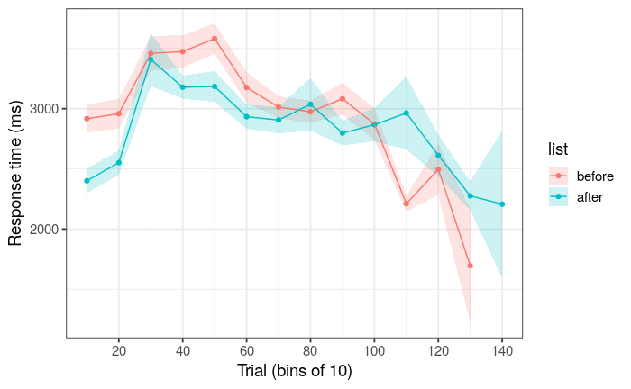

```r
binsize <- 10

d %>%
  mutate(part = cut(trial_index - 2, seq(0, max(trial_index) + 3, by = binsize), labels = F) * binsize) %>%
  filter(study == FALSE) %>%
  filter(correct) %>%
  group_by(subject, list, part) %>%
  summarise(rt = median(rt)) %>%
  group_by(list, part) %>%
  summarise(rt_se = sd(rt)/sqrt(n()),
            rt = mean(rt)) %>%
  ggplot(aes(x = part, y = rt, group = list, colour = list)) +
  geom_ribbon(aes(ymin = rt - rt_se, ymax = rt + rt_se, fill = list), alpha = 0.2, colour = NA) +
  geom_point() +
  geom_line() +
  scale_x_continuous(breaks = seq(0, 200, by = 20)) +
  labs(x = paste0("Trial (bins of ", binsize, ")"),
       y = "Response time (ms)")
```

We can make a similar plot with the presentation count on the x-axis. Study trials are included in this plot (presentation = 1), but incorrect/missing responses are again filtered out. This plot suggests that RT is consistently lower in the post-march session, particularly for the first few repetitions of an item.

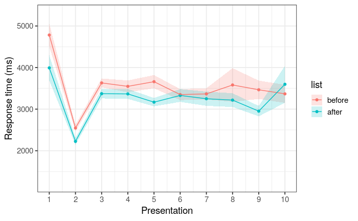

```r
d %>%
  # filter(study == FALSE) %>%
  filter(correct) %>%
  group_by(subject, list, presentation) %>%
  summarise(rt = median(rt)) %>%
  group_by(list, presentation) %>%
  summarise(rt_se = sd(rt)/sqrt(n()),
            rt = mean(rt)) %>%
  ggplot(aes(x = presentation, y = rt, group = list, colour = list)) +
  geom_ribbon(aes(ymin = rt - rt_se, ymax = rt + rt_se, fill = list), alpha = 0.2, colour = NA) +
  geom_point() +
  geom_line() +
  scale_x_continuous(limits = c(1, 10), breaks = 1:10) +
  labs(x = paste0("Presentation"),
       y = "Response time (ms)")
```

A plot of RT over time (study trials and incorrect/missing trials filtered out) presents a similar view: responses are faster at the start of the post-march session.

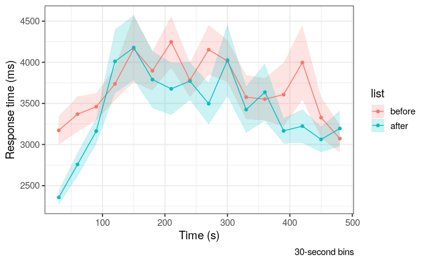

```r
binsize_time <- 30

d %>%
  filter(study == FALSE) %>%
  filter(correct) %>%
  group_by(subject, list) %>%
  mutate(time = (start_time - min(start_time))/1000) %>%
  ungroup() %>%
  mutate(part = cut(time, seq(0, max(time) + 10, by = binsize_time), labels = F, include.lowest = TRUE) * binsize_time) %>%
  group_by(subject, list, part) %>%
  summarise(rt = median(rt)) %>%
  group_by(list, part) %>%
  summarise(rt_se = sd(rt)/sqrt(n()),
            rt = mean(rt)) %>%
  ggplot(aes(x = part, y = rt, group = list, colour = list)) +
  geom_ribbon(aes(ymin = rt - rt_se, ymax = rt + rt_se, fill = list), alpha = 0.2, colour = NA) +
  geom_point() +
  geom_line() +
  labs(x = paste0("Time (s)"),
       y = "Response time (ms)",
       caption = "30-second bins")
```

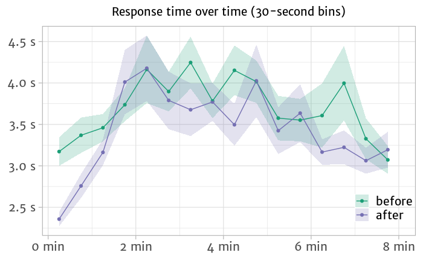

```r
binsize_time <- 30

d %>%
  filter(study == FALSE) %>%
  filter(correct) %>%
  group_by(subject, list) %>%
  mutate(time = (start_time - min(start_time))/1000) %>%
  ungroup() %>%
  mutate(part = cut(time, seq(0, max(time) + 10, by = binsize_time), labels = F, include.lowest = TRUE) * binsize_time) %>%
  group_by(subject, list, part) %>%
  summarise(rt = median(rt)) %>%
  group_by(list, part) %>%
  summarise(rt_se = (sd(rt)/sqrt(n()) / 1000),
            rt = mean(rt) / 1000) %>%
  ggplot(aes(x = (part - binsize_time/2)/60, y = rt, group = list, colour = list)) +
  geom_ribbon(aes(ymin = rt - rt_se, ymax = rt + rt_se, fill = list), alpha = 0.2, colour = NA) +
  geom_point() +
  geom_line() +
  scale_x_continuous(labels = scales::unit_format(unit = "min")) +
  scale_y_continuous(labels = scales::unit_format(accuracy = .1, unit = "s")) +
  scale_colour_manual(values = colours_custom) +
  scale_fill_manual(values = colours_custom) +
  expand_limits(x = 8.0001) + # Avoid "8 min" label being cut off
  labs(x = NULL,
       y = NULL,
       title = "Response time over time (30-second bins)",
       colour = NULL,
       fill = NULL) +
  theme_poster +
  theme(legend.position = c(.915,0.15))

ggsave("../output/rt_over_time.pdf", device = "pdf", width = 7, height = 3.5)
```

# Conclusions

The effects of the speed march on performance in the fact learning task are as follows:

- Participants completed 6 more trials in the post-march session.
- Participants encountered 1.5 more facts in the post-march session.
- Average response accuracy was the same between sessions (though accuracy was lower post-march at the start of the session).
- Response times were about 350 ms faster after the speed march (again, this effect seems to occur primarily at the start of the session).
- There was a small difference in final rate of forgetting estimates pre- and post-march, with post-march estimates being a bit lower.